# 52414 - lab 1

### Q5

### Open Question

10 points

Write an interesting research question regarding the Corona outbreak and then follow the steps to answer it using tables and plots. You can use the loaded datasets or any other dataset you find as long as you add the data file to your `lab1` repository so it can be loaded directly from a `url` (e.g. the World Bank). This question will be graded based on creativity, originality, and the novelty of the analysis.

**Solution:**

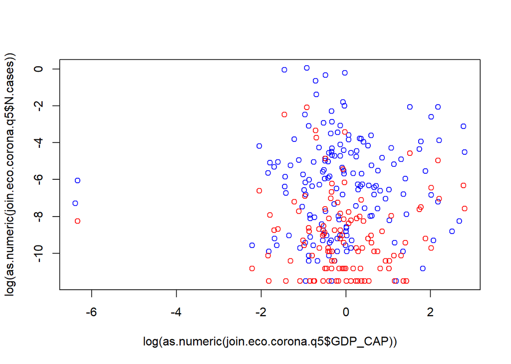

```r
## The question is: If the is a correlatio between amout of Cases (blue) or Deaths (red) and the GDP per capita
join.eco.corona.q5 <- join.eco.corona %>% filter(Date == "2020-03-31")
join.eco.corona.q5 <- join.eco.corona.q5 %>% mutate(GDP_CAP = as.numeric(GDP) / as.numeric(pop_total_columns))

plot(log(as.numeric(join.eco.corona.q5$GDP_CAP)), log(as.numeric(join.eco.corona.q5$N.cases)), col = "blue")
points(log(as.numeric(join.eco.corona.q5$GDP_CAP)), log(as.numeric(join.eco.corona.q5$N.deaths)), col = "red")
```

```r
# From the plot we can see that there is'nt correlation between variables, the amout of monety's country does'nt 'help' to pepole not to sick and even not to die.
```